# (Ford GoBike System Data Exploration)

## Preliminary Wrangling

> This analysis for data set includes information about individual rides made in a bike-sharing system covering the greater San Francisco Bay area. Each trip has it's own data like start and end time , start and end station with the station name , id and location, bike id and member gender

```python
# import all packages and set plots to be embedded inline
import numpy as np
import pandas as pd
import matplotlib.pyplot as plt
import seaborn as sb

%matplotlib inline
```

```python
ford = pd.read_csv('fordgobike-tripdata.csv')
ford.head()
```

|  | duration_sec | start_time | end_time | start_station_id | start_station_name | start_station_latitude | start_station_longitude | end_station_id | end_station_name | end_station_latitude | end_station_longitude | bike_id | user_type | member_birth_year | member_gender | bike_share_for_all_trip |
| --- | --- | --- | --- | --- | --- | --- | --- | --- | --- | --- | --- | --- | --- | --- | --- | --- |
| 0 | 52185 | 2019-02-28 17:32:10.1450 | 2019-03-01 08:01:55.9750 | 21.0 | Montgomery St BART Station (Market St at 2nd St) | 37.789625 | -122.400811 | 13.0 | Commercial St at Montgomery St | 37.794231 | -122.402923 | 4902 | Customer | 1984.0 | Male | No |
| 1 | 42521 | 2019-02-28 18:53:21.7890 | 2019-03-01 06:42:03.0560 | 23.0 | The Embarcadero at Steuart St | 37.791464 | -122.391034 | 81.0 | Berry St at 4th St | 37.775880 | -122.393170 | 2535 | Customer | NaN | NaN | No |
| 2 | 61854 | 2019-02-28 12:13:13.2180 | 2019-03-01 05:24:08.1460 | 86.0 | Market St at Dolores St | 37.769305 | -122.426826 | 3.0 | Powell St BART Station (Market St at 4th St) | 37.786375 | -122.404904 | 5905 | Customer | 1972.0 | Male | No |
| 3 | 36490 | 2019-02-28 17:54:26.0100 | 2019-03-01 04:02:36.8420 | 375.0 | Grove St at Masonic Ave | 37.774836 | -122.446546 | 70.0 | Central Ave at Fell St | 37.773311 | -122.444293 | 6638 | Subscriber | 1989.0 | Other | No |
| 4 | 1585 | 2019-02-28 23:54:18.5490 | 2019-03-01 00:20:44.0740 | 7.0 | Frank H Ogawa Plaza | 37.804562 | -122.271738 | 222.0 | 10th Ave at E 15th St | 37.792714 | -122.248780 | 4898 | Subscriber | 1974.0 | Male | Yes |

```python
ford.shape
```

```
(183412, 16)
```

```python
ford.info()
```

```
<class 'pandas.core.frame.DataFrame'>
RangeIndex: 183412 entries, 0 to 183411
Data columns (total 16 columns):
 #   Column                   Non-Null Count   Dtype
---  ------                   --------------   -----
 0   duration_sec             183412 non-null  int64
 1   start_time               183412 non-null  object
 2   end_time                 183412 non-null  object
 3   start_station_id         183215 non-null  float64
 4   start_station_name       183215 non-null  object
 5   start_station_latitude   183412 non-null  float64
 6   start_station_longitude  183412 non-null  float64
 7   end_station_id           183215 non-null  float64
 8   end_station_name         183215 non-null  object
 9   end_station_latitude     183412 non-null  float64
 10  end_station_longitude    183412 non-null  float64
 11  bike_id                  183412 non-null  int64
 12  user_type                183412 non-null  object
 13  member_birth_year        175147 non-null  float64
 14  member_gender            175147 non-null  object
 15  bike_share_for_all_trip  183412 non-null  object
dtypes: float64(7), int64(2), object(7)
memory usage: 22.4+ MB
```

```python
ford.isnull().sum()
```

```
duration_sec                  0
start_time                    0
end_time                      0
start_station_id            197
start_station_name          197
start_station_latitude        0
start_station_longitude       0
end_station_id              197
end_station_name            197
end_station_latitude          0
end_station_longitude         0
bike_id                       0
user_type                     0
member_birth_year          8265
member_gender              8265
bike_share_for_all_trip       0
dtype: int64
```

```python
#Remove all null cells , they are less than 1% of the whole data
ford_bike = ford.dropna()
ford_bike.isnull().sum()
```

```
duration_sec               0
start_time                 0
end_time                   0
start_station_id           0
start_station_name         0
start_station_latitude     0
start_station_longitude    0
end_station_id             0
end_station_name           0
end_station_latitude       0
end_station_longitude      0
bike_id                    0
user_type                  0
member_birth_year          0
member_gender              0
bike_share_for_all_trip    0
dtype: int64
```

```python
ford_bike.shape
```

```
(174952, 16)
```

```python
ford_bike.info()
```

```
<class 'pandas.core.frame.DataFrame'>
Int64Index: 174952 entries, 0 to 183411
Data columns (total 16 columns):
 #   Column                   Non-Null Count   Dtype
---  ------                   --------------   -----
 0   duration_sec             174952 non-null  int64
 1   start_time               174952 non-null  object
 2   end_time                 174952 non-null  object
 3   start_station_id         174952 non-null  float64
 4   start_station_name       174952 non-null  object
 5   start_station_latitude   174952 non-null  float64
 6   start_station_longitude  174952 non-null  float64
 7   end_station_id           174952 non-null  float64
 8   end_station_name         174952 non-null  object
 9   end_station_latitude     174952 non-null  float64
 10  end_station_longitude    174952 non-null  float64
 11  bike_id                  174952 non-null  int64
 12  user_type                174952 non-null  object
 13  member_birth_year        174952 non-null  float64
 14  member_gender            174952 non-null  object
 15  bike_share_for_all_trip  174952 non-null  object
dtypes: float64(7), int64(2), object(7)
memory usage: 22.7+ MB
```

```python
#change the start time and end time type
ford_bike['start_time'] = pd.to_datetime(ford_bike['start_time'])
ford_bike['end_time'] = pd.to_datetime(ford_bike['end_time'])
```

```python
#extract day and hour from start_time
ford_bike.loc[: ,'start_time_day'] = ford_bike['start_time'].dt.strftime('%a')
ford_bike.loc[:, 'start_time_hour'] = ford_bike['start_time'].dt.hour
```

```python
#extract day and hour from end_time
ford_bike.loc[:,'end_time_day'] = ford_bike['end_time'].dt.strftime('%a')
ford_bike.loc[:,'end_time_hour'] = ford_bike['end_time'].dt.hour
```

```python
ford_bike.info()
```

[output not shown]

```python
#confirm no duplicates
ford.duplicated().sum()
```

```
0
```

```python
#calculate members age
ford_bike.loc[:,'member_age'] = 2019 - ford_bike.loc[:,'member_birth_year']
ford_bike.loc[:,'member_age'] = ford_bike.loc[:, 'member_age'].astype(int)
```

```python
ford_bike.head()
```

[output not shown]

5 rows × 22 columns

```python
# sort ordinary data
days = ['Mon', 'Tue', 'Wed', 'Thu', 'Fri', 'Sat', 'Sun']
daysoftheweek = pd.api.types.CategoricalDtype(ordered=True, categories = days)
ford_bike.loc[:, 'start_time_day'] = ford_bike.loc[:, 'start_time_day'].astype(daysoftheweek)
ford_bike.loc[:, 'end_time_day'] = ford_bike.loc[:, 'end_time_day'].astype(daysoftheweek)
```

```python
ford_bike.info()
```

[output not shown]

```python
ford_bike.shape
```

[output not shown]

### What is the structure of your dataset?

Data set has more than 174k bike sharing ride data covering the greater San Francisco Bay in 2019, Data set has lot of data like:

- Ride ID
- Start and End station
- Start and End time
- Member age and Gender

### Plus I added the following feautre :

- Member age
- Start and end day and hour

### What is/are the main feature(s) of interest in your dataset?

> I will investigate what the most visited station , peak days and hour .

### What features in the dataset do you think will help support your investigation into your feature(s) of interest?

> I think the following feature will help me:
> - trip duration
> - start and end day and hour
> - Member gender and age
> - User type

## Univariate Exploration

> In this section, investigate distributions of individual variables. If you see unusual points or outliers, take a deeper look to clean things up and prepare yourself to look at relationships between variables.

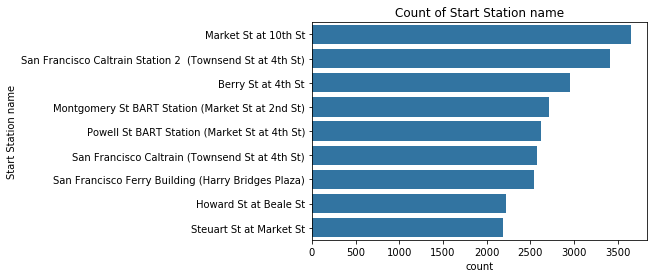

```python
base_color = sb.color_palette()[0]
order = ford_bike['start_station_name'].value_counts().index[0:9]
sb.countplot(data= ford_bike, y='start_station_name',color=base_color,order=order);
plt.ylabel('Start Station name');
plt.title('Count of Start Station name');
```

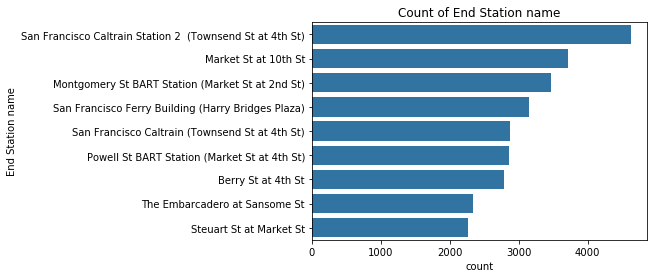

```python
base_color = sb.color_palette()[0]
order = ford_bike['end_station_name'].value_counts().index[0:9]
sb.countplot(data= ford_bike, y='end_station_name',color=base_color,order=order);
plt.ylabel('End Station name');
plt.title('Count of End Station name');
```

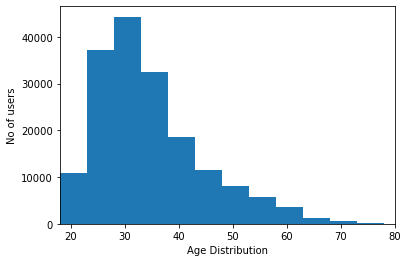

```python
bins = np.arange(18,100+5,5)
plt.hist(data=ford_bike ,x='member_age',bins=bins);
plt.xlim([18, 80])
plt.xlabel('Age Distribution');
plt.ylabel('No of users')
```

```python
ford_bike.member_age.mean()
```

```
34.196865425945404
```

> We can find peak in the age between 25 to 40

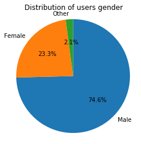

```python
#matplotlib.pyplot.pie(x_data, labels, colors, startangle, counterclock, wedgeprops)
ford_bike.loc[:,'member_gender'] = ford_bike.loc[:, 'member_gender'].astype(str)
sorted_counts = ford_bike['member_gender'].value_counts()
plt.pie(sorted_counts, labels = sorted_counts.index, startangle = 90,
        counterclock = False, autopct='%1.1f%%');
plt.axis('square');
plt.title('Distribution of users gender');
```

> 74% of the customer are males and 23.3% are females

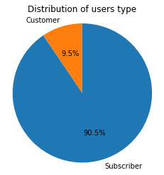

```python
sorted_counts = ford_bike['user_type'].value_counts()
plt.pie(sorted_counts, labels = sorted_counts.index, startangle = 90,
        counterclock = False, autopct='%1.1f%%');
plt.axis('square');
plt.title('Distribution of users type');
```

> 90% of the users are subscriber

```python
#create new colomn for trip duration mins
ford_bike.loc[:, 'duration_min'] = ford_bike['duration_sec']/60
```

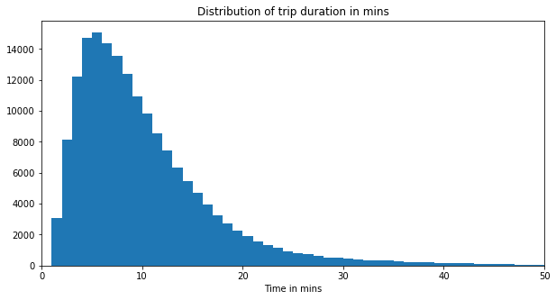

```python
plt.figure(figsize = [10, 5])
bins = np.arange(ford_bike['duration_min'].min(), ford_bike['duration_min'].max()+1, 1)
plt.hist(data = ford_bike, x = 'duration_min', bins = bins);
plt.xlim([0, 50]);
plt.title('Distribution of trip duration in mins')
plt.xlabel('Time in mins');
```

> Most trip duration less than 20 mins , but we can find tale in th graph so better to use the log scale

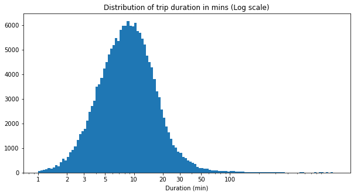

```python
#There is a tale in the previous graph so we will use log scale
plt.figure(figsize = [10, 5])
plt.xscale('log')
np.log10(ford_bike['duration_min'].describe())
bins = 10 ** np.arange(0, 3.1+0.025, 0.025)
ticks = [1, 2, 3, 5, 10, 20, 30, 50, 100]
labels = ['{}'.format(v) for v in ticks]
plt.hist(data=ford_bike, x='duration_min', bins=bins);
plt.xscale('log')
plt.xlabel('Duration (min)')
plt.xticks(ticks, labels);
plt.title('Distribution of trip duration in mins (Log scale)');
```

> Data now looks closer to normal distribution

```python
np.log10(ford_bike['duration_min'].describe())
```

```
count    5.242919
mean     1.069423
std      1.437276
min      0.007179
25%      0.731051
50%      0.929419
75%      1.118926
max      3.148952
Name: duration_min, dtype: float64
```

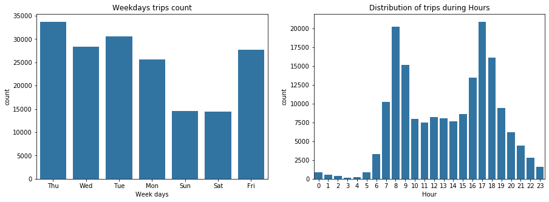

```python
#let's check the most peak day and hour
plt.figure(figsize = [15, 5])
base_color = sb.color_palette()[0]
plt.subplot(1, 2, 1)
sb.countplot(data=ford_bike, x='start_time_day', color=base_color);
plt.xlabel('Week days');
plt.title('Weekdays trips count');
plt.subplot(1, 2, 2)
sb.countplot(data=ford_bike, x='start_time_hour', color=base_color);
plt.xlabel('Hour');
plt.title('Distribution of trips during Hours');
```

## Bivariate Exploration

> In this section, investigate relationships between pairs of variables in your data. Make sure the variables that you cover here have been introduced in some fashion in the previous section (univariate exploration).

```python
ford_bike.head()
```

|  | duration_sec | start_time | end_time | start_station_id | start_station_name | start_station_latitude | start_station_longitude | end_station_id | end_station_name | end_station_latitude | ... | user_type | member_birth_year | member_gender | bike_share_for_all_trip | start_time_day | start_time_hour | end_time_day | end_time_hour | member_age | duration_min |
| --- | --- | --- | --- | --- | --- | --- | --- | --- | --- | --- | --- | --- | --- | --- | --- | --- | --- | --- | --- | --- | --- |
| 0 | 52185 | 2019-02-28 17:32:10.145 | 2019-03-01 08:01:55.975 | 21.0 | Montgomery St BART Station (Market St at 2nd St) | 37.789625 | -122.400811 | 13.0 | Commercial St at Montgomery St | 37.794231 | ... | Customer | 1984.0 | Male | No | Thu | 17 | Fri | 8 | 35 | 869.750000 |
| 2 | 61854 | 2019-02-28 12:13:13.218 | 2019-03-01 05:24:08.146 | 86.0 | Market St at Dolores St | 37.769305 | -122.426826 | 3.0 | Powell St BART Station (Market St at 4th St) | 37.786375 | ... | Customer | 1972.0 | Male | No | Thu | 12 | Fri | 5 | 47 | 1030.900000 |
| 3 | 36490 | 2019-02-28 17:54:26.010 | 2019-03-01 04:02:36.842 | 375.0 | Grove St at Masonic Ave | 37.774836 | -122.446546 | 70.0 | Central Ave at Fell St | 37.773311 | ... | Subscriber | 1989.0 | Other | No | Thu | 17 | Fri | 4 | 30 | 608.166667 |
| 4 | 1585 | 2019-02-28 23:54:18.549 | 2019-03-01 00:20:44.074 | 7.0 | Frank H Ogawa Plaza | 37.804562 | -122.271738 | 222.0 | 10th Ave at E 15th St | 37.792714 | ... | Subscriber | 1974.0 | Male | Yes | Thu | 23 | Fri | 0 | 45 | 26.416667 |
| 5 | 1793 | 2019-02-28 23:49:58.632 | 2019-03-01 00:19:51.760 | 93.0 | 4th St at Mission Bay Blvd S | 37.770407 | -122.391198 | 323.0 | Broadway at Kearny | 37.798014 | ... | Subscriber | 1959.0 | Male | No | Thu | 23 | Fri | 0 | 60 | 29.883333 |

5 rows × 22 columns

```python
ford_bike.info()
```

```
<class 'pandas.core.frame.DataFrame'>
Int64Index: 174952 entries, 0 to 183411
Data columns (total 22 columns):
 #   Column                   Non-Null Count   Dtype
---  ------                   --------------   -----
 0   duration_sec             174952 non-null  int64
 1   start_time               174952 non-null  datetime64[ns]
 2   end_time                 174952 non-null  datetime64[ns]
 3   start_station_id         174952 non-null  float64
 4   start_station_name       174952 non-null  object
 5   start_station_latitude   174952 non-null  float64
 6   start_station_longitude  174952 non-null  float64
 7   end_station_id           174952 non-null  float64
 8   end_station_name         174952 non-null  object
 9   end_station_latitude     174952 non-null  float64
 10  end_station_longitude    174952 non-null  float64
 11  bike_id                  174952 non-null  int64
 12  user_type                174952 non-null  object
 13  member_birth_year        174952 non-null  float64
 14  member_gender            174952 non-null  object
 15  bike_share_for_all_trip  174952 non-null  object
 16  start_time_day           174952 non-null  category
 17  start_time_hour          174952 non-null  int64
 18  end_time_day             174952 non-null  category
 19  end_time_hour            174952 non-null  int64
 20  member_age               174952 non-null  int32
 21  duration_min             174952 non-null  float64
dtypes: category(2), datetime64[ns](2), float64(8), int32(1), int64(4), object(5)
memory usage: 31.7+ MB
```

```python
numeric_vars = ['duration_sec', 'start_time', 'end_time', 'start_station_id', 'start_station_latitude', 'start_station_longitude', 'end_station_id', 'end_station_latitude',
'end_station_longitude', 'bike_id', 'member_birth_year', 'member_age', 'duration_min']
numeric_vars = ['duration_min', 'member_age']
categoric_vars = ['start_time_dayofweek', 'start_time_hour', 'member_gender', 'user_type']
```

```python
numeric_vars = ['duration_sec', 'start_time', 'end_time', 'start_station_id', 'start_station_latitude', 'start_station_longitude', 'end_station_id', 'end_station_latitude',
'end_station_longitude', 'bike_id', 'member_birth_year', 'member_age', 'duration_min']
categoric_vars = ['user_type', 'member_gender', 'start_time_day']
```

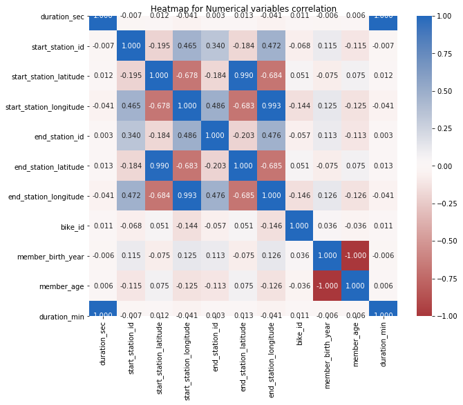

```python
#plot a heatmap to get the correlation between the numeric variables

plt.figure(figsize = [10, 8])
sb.heatmap(ford_bike[numeric_vars].corr(), annot = True, fmt = '.3f',
           cmap = 'vlag_r', center = 0);


plt.title('Heatmap for Numerical variables correlation');
```

> I can't find strong correlation between the most of the numerical variables so I will create new list of numerical variables suspected I will get correlation between them

```python
new_numerical = [ 'member_age', 'duration_min']
ford_sub = ford_bike.loc[ford_bike['duration_min'] < 800]
```

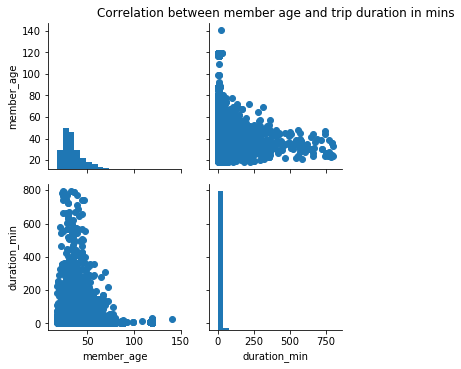

```python
g = sb.PairGrid(data = ford_sub, vars = new_numerical);
g = g.map_diag(plt.hist, bins = 20);
g.map_offdiag(plt.scatter);
plt.title('Correlation between member age and trip duration in mins');
```

> can't find clear correlation between the age member and duration time

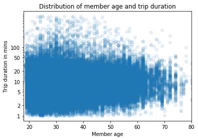

```python
#plot the relation between the member age and trip duration
plt.scatter(data = ford_sub, x = 'member_age', y = 'duration_min', alpha = 1/10);
plt.xlabel('Member age')
plt.ylabel('Trip duration in mins');
plt.yscale('log');
plt.yticks([1, 2, 5, 10, 20, 50, 100], [1, 2, 5, 10, 20, 50, 100]);
plt.xlim([18, 80]);

plt.title('Distribution of member age and trip duration');
```

> I can notice that trip duration higher in age 20's and 30's

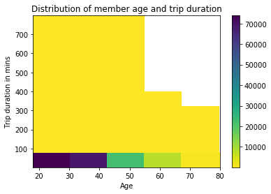

```python
#let's use heatmap to confirm
plt.hist2d(data = ford_sub, x = 'member_age', y = 'duration_min', cmin=0.5, cmap='viridis_r')
plt.colorbar();
plt.xlim([18, 80]);
plt.xlabel('Age')
plt.ylabel('Trip duration in mins')
plt.title('Distribution of member age and trip duration');
```

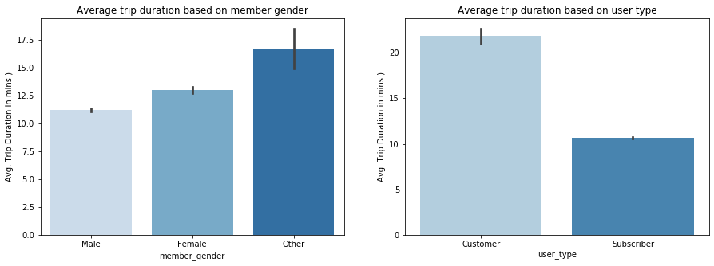

```python
#let's check the relation between average trip duration and both user type and member gender
plt.figure(figsize = [15, 5])
plt.subplot(1, 2, 1)
sb.barplot(data = ford_bike, x = 'member_gender', y = 'duration_min', palette='Blues', order = ford_bike['member_gender'].value_counts().index)
plt.ylabel('Avg. Trip Duration in mins )');
plt.title('Average trip duration based on member gender');


plt.subplot(1, 2, 2)
sb.barplot(data = ford_bike, x = 'user_type', y = 'duration_min', palette='Blues')
plt.ylabel('Avg. Trip Duration in mins )');
plt.title('Average trip duration based on user type');
```

> surprisely the average trip duration high in the user_type(customer) not in the (subscriber) , and females greater than males

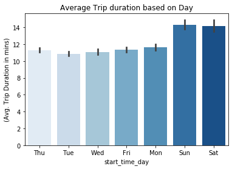

```python
sb.barplot(data = ford_bike, x = 'start_time_day', y = 'duration_min', palette='Blues',order=ford_bike.start_time_day.value_counts().index)
plt.ylabel('(Avg. Trip Duration in mins)');
plt.title('Average Trip duration based on Day');
```

> Saturday and Sunday are the highest day in the trip duration time

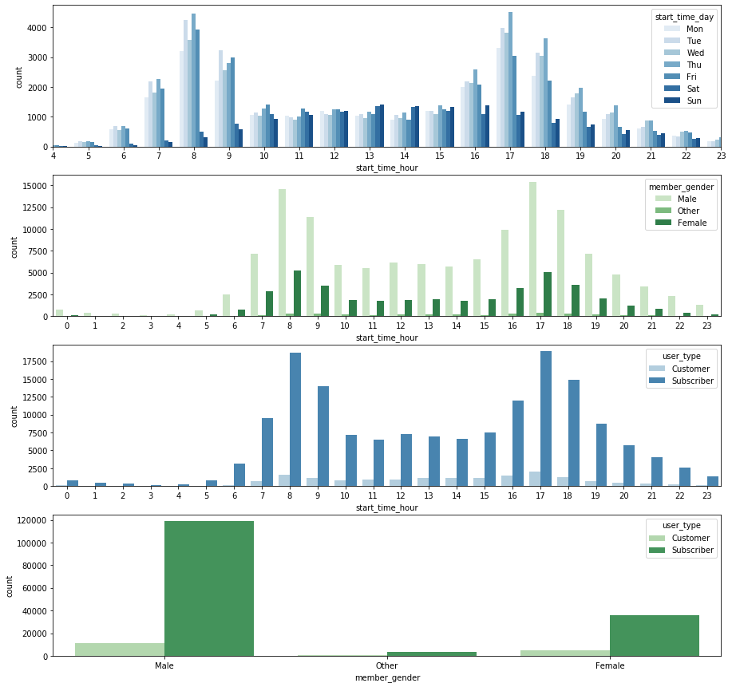

```python
plt.figure(figsize=[15,15])
plt.subplot(4, 1, 1)
sb.countplot(data = ford_bike, x = 'start_time_hour', hue = 'start_time_day', palette = 'Blues');
plt.xlim([4,23])
plt.subplot(4, 1, 2)
sb.countplot(data = ford_bike, x = 'start_time_hour', hue = 'member_gender', palette = 'Greens')
plt.subplot(4, 1, 3)
sb.countplot(data = ford_bike, x = 'start_time_hour', hue = 'user_type', palette = 'Blues')
plt.subplot(4, 1, 4)
sb.countplot(data = ford_bike, x = 'member_gender', hue = 'user_type', palette = 'Greens');
```

> Male Peak hour is 5:00pm while female peak hour is 8 am

> also subscriber peak hours are 8am and 5 pm but the customer peak hour is 5pm

> Male customers and subscribers are larger than female customers and subscribers

### Talk about some of the relationships you observed in this part of the investigation. How did the feature(s) of interest vary with other features in the dataset?

> By doing scatter plot and heatmap relation between the trip duration and member age I can notice that trip duration higher in age 20's and 30's

> Saturday and Sunday (weekend-days) are the highest day in the trip duration time

> Male Peak hour is 5:00pm while female peak hour is 8 am

> Also subscriber peak hours are 8am and 5 pm but the customer peak hour is 5pm

> Male customers and subscribers are larger than female customers and subscribers

### Did you observe any interesting relationships between the other features (not the main feature(s) of interest)?

> Female average trip duration time is larger than males

> Customers average trip duration time is larger than subscriber

## Multivariate Exploration

> Create plots of three or more variables to investigate your data even further. Make sure that your investigations are justified, and follow from your work in the previous sections.

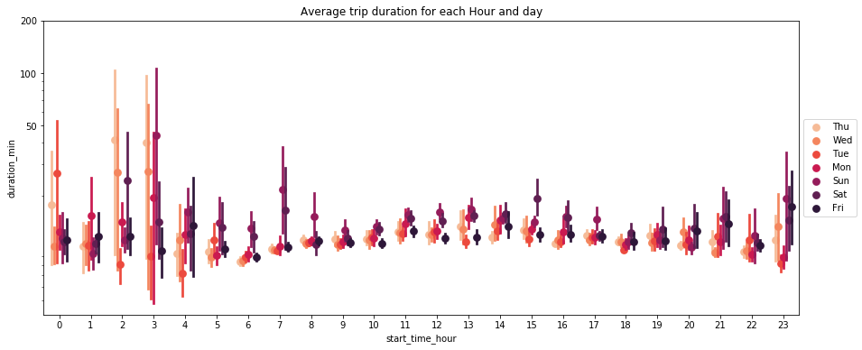

```python
plt.figure(figsize=[15,6])

g = sb.pointplot(data = ford_bike, x = 'start_time_hour', y = 'duration_min', hue = 'start_time_day',
             dodge = 0.5, linestyles = "",palette='rocket_r')
plt.yscale('log')
plt.yticks([50,100,200], [50,100,200]);
plt.legend(loc = 6, bbox_to_anchor = (1.0, 0.5));
plt.title('Average trip duration for each Hour and day');
```

> Saturday and Sunday are the largest day in the trip duration On Sunday the largest trip duration at 3:00 am

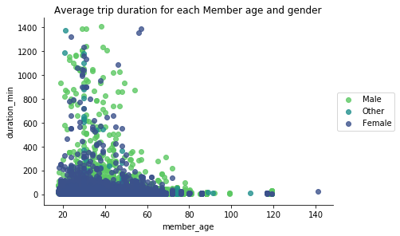

```python
plt.figure(figsize=[20,6]);
g = sb.FacetGrid(data = ford_bike, hue = 'member_gender', size = 4, aspect = 1.5, palette = 'viridis_r')
g.map(sb.regplot, 'member_age', 'duration_min', x_jitter = 0.04, fit_reg = False );
plt.legend(loc = 6, bbox_to_anchor = (1.0, 0.5));
plt.title('Average trip duration for each Member age and gender');
```

> The majority of females below 200 min for trip duration and the Males customers has outliners

### Talk about some of the relationships you observed in this part of the investigation. Were there features that strengthened each other in terms of looking at your feature(s) of interest?

> I belive we almost have the same findings from the bivarial section

### Were there any interesting or surprising interactions between features?

> Yes , when I found that 3 am is the most trip duration on sunday

> Female bikers bike longer on average compared to male bikers.

> and when find the 'customer' user type has longer on average compared to 'Subscriber' bikers.